# Developing Data Products Course Project

12/2/2018

## Introduction

- This shiny app uses R's built-in dataset "airquality" to build simple linear models and predict Ozone value in the dataset.
- The app is designed so that users can customize the predictors they wish to use, and specify values of those predictors. The app will then build a simple linear model of those predictors, and make a prediction of Ozone value based on input predictor values.
- The source code of ui.R and server.R file can be found [here](https://github.com/perfectslumber/DataScienceCoursera/tree/master/Developing%20Data%20Products%20Course%20Project/Airquality_Linear_Model).
- If users choose only one predictor, the app will also draw a fitted plot of its relationship with Ozone. We can tell there are some level of linear relationship in there (see slide 4).
- Users can choose up to 4 predictors to build the linear model.

## A summary of "airquality" dataset

Observations with missing values are removed when building the model.

```r
summary(airquality)
```

```
     Ozone           Solar.R           Wind             Temp
 Min.   :  1.00   Min.   :  7.0   Min.   : 1.700   Min.   :56.00
 1st Qu.: 18.00   1st Qu.:115.8   1st Qu.: 7.400   1st Qu.:72.00
 Median : 31.50   Median :205.0   Median : 9.700   Median :79.00
 Mean   : 42.13   Mean   :185.9   Mean   : 9.958   Mean   :77.88
 3rd Qu.: 63.25   3rd Qu.:258.8   3rd Qu.:11.500   3rd Qu.:85.00
 Max.   :168.00   Max.   :334.0   Max.   :20.700   Max.   :97.00
 NA's   :37       NA's   :7
     Month            Day
 Min.   :5.000   Min.   : 1.0
 1st Qu.:6.000   1st Qu.: 8.0
 Median :7.000   Median :16.0
 Mean   :6.993   Mean   :15.8
 3rd Qu.:8.000   3rd Qu.:23.0
 Max.   :9.000   Max.   :31.0
```

## Simple linear regression with one predictor

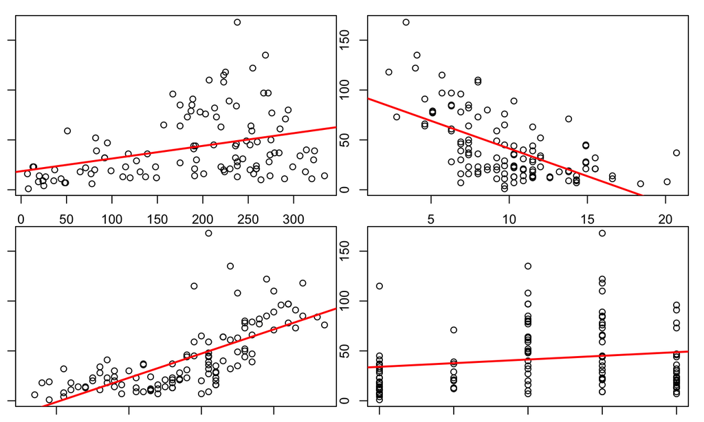

## Conslusion

This app builds simple linear models to predictor Ozone value in "airquality" dataset based on user input. This app only builds a simple linear model based on selected predictors and input, which may give negative or weird Ozone values due to its limitations. More advanved regression model is required to precisely predict Ozone values.